# Instructions: Homework #4

Data Science for Biologists, Fall 2021

Complete the template Rmd and submit to Canvas on Wednesday 10/6/21 by 2 PM

## Instructions

For this assignment you will be *recreating plots shown in these instructions* made from the `sparrows` dataset, which we saw during in-class exercises using `ggplot2`. The `sparrows` dataset is part of the `ds4b.materials` package, so by loading that library, you are loading that dataset.

### Obtaining and setting up the homework

- Obtain the homework from your RStudio Cloud class project by running the following code in the R Console:

  ```r
  library(ds4b.materials) # Load the class library
  launch_homework(4)      # Launch Homework 4
  ```

- Answer each question with appropriate code and comments in the given question’s R chunk. Chunks are *named* as `plot1` for plot 1, `plot2` for plot 2, etc.
- You must set an *RMarkdown theme and code syntax highlighting scheme* of your choosing in the YAML front matter. These links will help you:
  - Choose your favorite *theme* among the **pre-packaged themes** (ignore everything below “Even More Themes”) shown at [this link](https://www.datadreaming.org/post/r-markdown-theme-gallery/)
  - Choose your favorite *syntax highlighting* among these options at [this link](https://www.garrickadenbuie.com/blog/pandoc-syntax-highlighting-examples/)
- **Make sure your Rmd knits without errors before submitting.** If it does not produce an HTML output, this means it does not knit. *DO NOT SKIP THIS STEP!* Ensuring code runs without errors is MORE IMPORTANT than writing code in the first place.
  - If there are errors in your code, you should *comment out* the code so that it does not actually run. This is **BETTER** than keeping the buggy code in there without commenting out - *it shows me you attempted the code, but understood that it didn’t work properly.* Partial credit will come to you! But, if you leave buggy code in, then the Rmd will not knit and there will be deductions.
- As always, you are encouraged to work together and use the class Slack to help each other out, but you must submit YOUR OWN CODE.

### Recreating the plots

> **Explore the dataset interactively in the Console before you begin plotting, and even then, keep looking at it!!** You cannot work with data that you aren’t looking at, and nobody ever expects you to. You might want to run `View(sparrows)` **in Console** (not in the RMarkdown!!) to keep a full view of the dataset open at all times.
1. For each question, you should write code to recreate the plot. *Save* the plot to a variable and *THEN* reveal the plot by typing out the variable. *The purpose of this instruction is to make you practice saving plots to variables!* For example (plots are small, for demo only):

   ```r
   ## YES!!
   # Make and save plot
   example_plot <- ggplot(iris) +
     aes(x = Sepal.Length) +
     geom_histogram()

   example_plot # reveal plot
   ```

   ```r
   ## YES!!
   # OR, assign *forwards* if you prefer that style:
   # Make and save plot
   ggplot(iris) +
     aes(x = Sepal.Length) +
     geom_histogram() -> example_plot

   example_plot # reveal plot
   ```

   ```r
   ## NO!! THIS DOESN'T SAVE TO A VARIABLE!! NO!!
   ggplot(iris) +
     aes(x = Sepal.Length) +
     geom_histogram()
   ```

2. Your code must be *spaced out onto separate lines* as we have learned in class. There will be deductions for plotting code that is all on one line. *The purpose of this instruction is to force you build this organizational habit as early as possible*. For example…

   ```r
   ## YES!!
   ggplot(iris) +
     aes(x = Sepal.Length) +
     geom_histogram() -> example_plot

   ## NO!!
   ggplot(iris) + aes(x = Sepal.Length) + geom_histogram() ->    example_plot
   ```

3. When recreating the plots, you **DO NOT NEED** to specifically recreate:
   - Exact colors and fills that appear in the plots. If the plots contain use “just a color” or “just a fill”, *you can use literally any color/fill you want, as long as you are specifying the same type of feature.* [Have fun](https://sjspielman.github.io/datascience_for_biologists/misc/Rcolor.pdf)!
   - Exact point or line size. For example, if a plot technically contains points that are `size=2` but yours do not, *that’s OK! No deductions!* You can’t really eyeball this stuff.
4. When recreating the plots, you **DO NEED** to make sure you recreate:
   - Matching axes labels and plot titles (hint: *there are titles!*)
   - Matching the geom used and its styling
   - The specific aesthetic mappings
   - The plot *theme*. For all plots, **ONLY of the following four themes is used**. You can see what the themes look like [here](https://ggplot2.tidyverse.org/reference/ggtheme.html) and/or [here](https://spielmanlab.github.io/introverse/introverse_docs/ggplot2_theme_gray.html)
     - `theme_classic()`
     - `theme_minimal()`
     - `theme_bw()`
     - `theme_gray()` (This is the default theme. If the plot uses this theme, you do NOT need to code it - it’s the default!)
     - (*Seriously*, NONE OF THE PLOTS USE: `theme_linedraw()` or `theme_light()`. Those do NOT APPEAR HERE!)
5. Ensure your code contains comments!! **Specifically, any line of code that you do not *immediately and like muscle-memory understand* should have a comment.** This helps you to develop the skill of commenting and understand what your own code does.
   - Please note: Many beginners feel “stupid” writing comments. Sometimes they think, “If I were good at coding, I wouldn’t need comments. Comments make me look like I’m not smart enough to code.” *This is a fundamental (but completely normal!) misunderstanding!* The best coders are the ones who make their code as easy as possible to read and re-use. *Using comments is a sign that you are a STRONG PROGRAMMER who knows how to write clear code. Not using comments is a sign that you enjoy pain and you love to forget what your code does 30 seconds after you wrote it.*
6. **Don’t make this harder than it has to be.** Every type of plot you have to make on this homework was introduced in lecture and/or the `ggplot2` interactive exercises. Unless the question explicitly teaches you new code, you have seen the code you need to use before.
7. You can place `aes()` wherever you want, as long as the plot works! You can include aesthetics on their own, within the `ggplot()` call, or within the relevant `geom` function. There is lots of flexibility for how you code aesthetic mappings, so use this opportunity to explore your coding style preference.
8. The `setup` R chunk in the RMarkdown template pre-specifies a default figure size of 6 inches wide and 4 inches tall. Don’t interfere with this setting!! The plots you need to recreate were also made to be 6 inches wide and 4 inches tall.

## Plots to recreate

### Plot 1

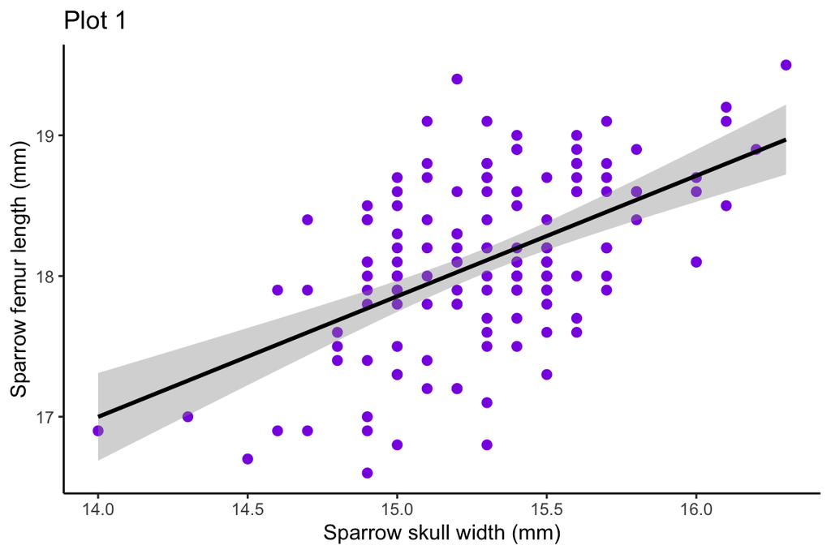

> Hints:
> - See how “Plot 1” is written twice? The first big/bold one is the question header for the homework, and the *second one is part of the plot.* All plots in this homework are structured like this.
> - Indeed that is a trendline you see! *For this trendline only, uniquely on the homework, make sure you match its specific color.* You don’t have to match other colors exactly. (The color is `"black"`).

### Plot 2

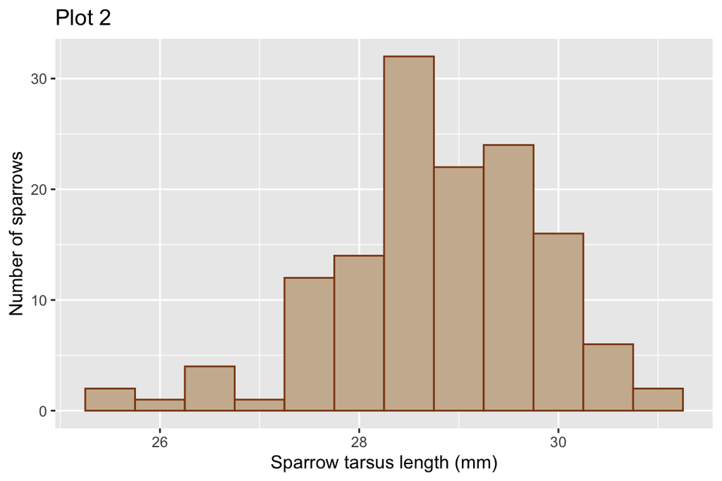

> Hint: You should use the *argument* `bins` with your geom to exactly match this plot. Count the number of bins and use that number!

### Plot 3

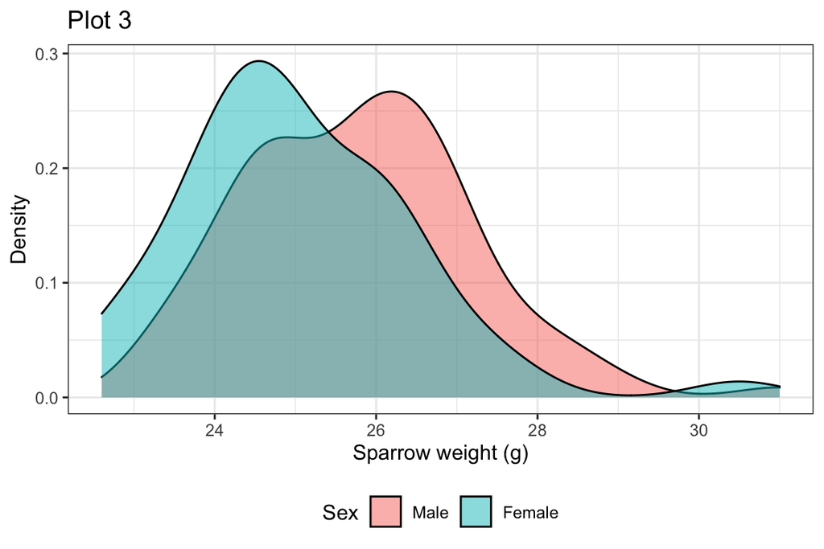

> Hints:
> - Notice that both distributons are visible even though they are overlapping. Make sure yours also features *transparency*!
> - This plot places the legend at the bottom of the plot. This is actually a modification to the plot’s theme. Because `ggplot` plots are just added components *on top of one another*, you will need to change the legend position AFTER you set its theme (think about why this MUST BE THE CASE, and experiment with it!). The legend can be re-positioned by adding on the following code: `theme(legend.position = "bottom")`. To learn more (but not to submit for this questoin!), see what happens if you use “top”, “left”, or “right” instead of “bottom”.

### Plot 4

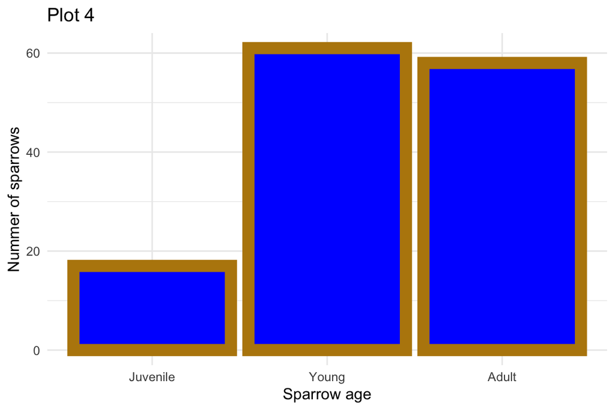

> - Make sure your *order of variables* agrees with this plot!! You will need to use the function `fct_relevel()`, which was introduced in the `ggplot2` exercises. Learn more by asking the `introverse` for help: `get_help("fct_relevel")`!!
> - This plot features both a fill and color!

### Plot 5

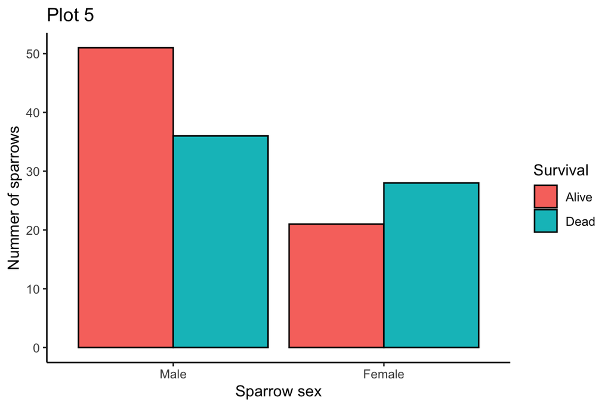

### Plot 6

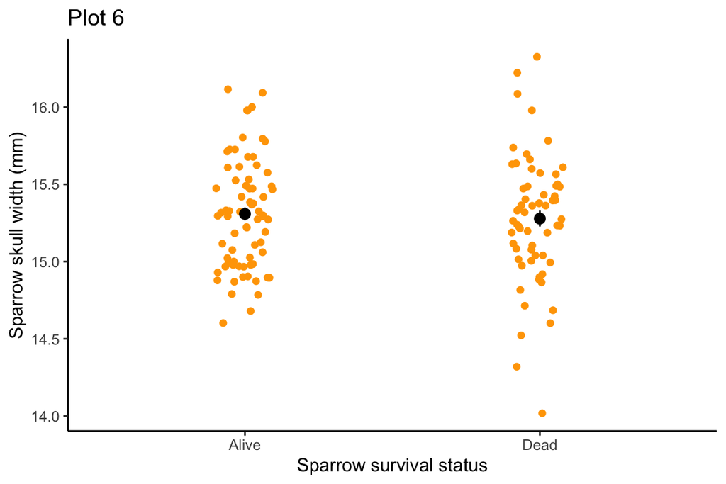

> Hints:
> - See the *black point with small lines* in each distribution? This represents the *mean and standard error (SE)* of each distribution. In this case, the standard errors are very small, so the lines are a bit tricky to see, but they are there! These points are conveniently, amazingly, and automatically added with the plot component, `stat_summary()`. This is a special `ggplot2` function which can easily add a *summary statistic* onto a plot. No arguments are necessary because *by default*, it plots mean and SE.
> - It will reveal a warning message: “No summary function supplied, defaulting to `mean_se()`,” which means you used it CORRECTLY!!!!!
> - You will see the black point is larger than the other points. You should also make sure your plot has these *relative* sizes, but the exact numbers can differ from mine.
> - You will want to use the argument `width` with your geom. Your value does not need to exactly match that used to make the plot, but it should definitely differ from the default.

### Plot 7

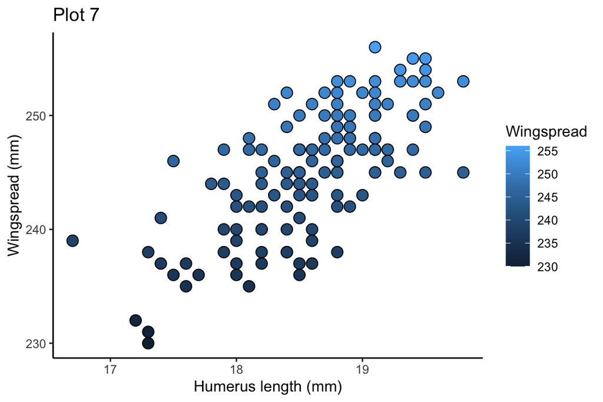

> Hint: These points have both a color and fill!

### Plot 8

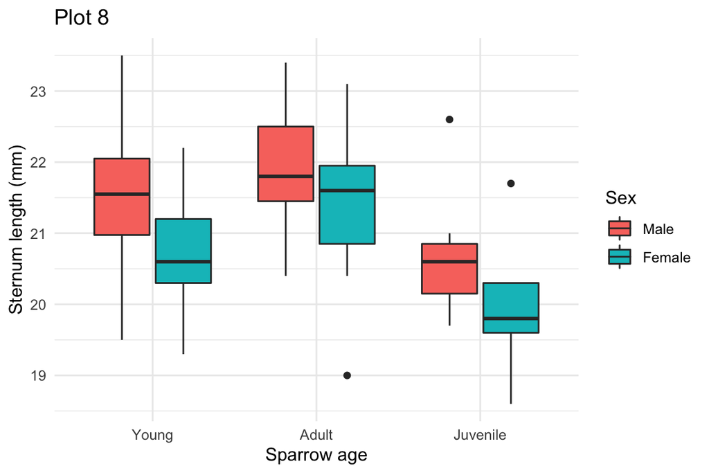

> Hint: Carefully consider the aesthetic mappings (`aes()`), and you will figure this out. It’s all about the mappings!! Think…

> What is on the X? What is on the Y? Is there a color or fill (hint: there’s a fill!)? Is that color/fill “just a fill” or mapped to a variable (hint: it’s mapped!)? Amazingly, this information alone is enough to get you almost all the way to the finish line, other than theme and labels. *The grammar of graphics is amazing!!*

### Plot 9

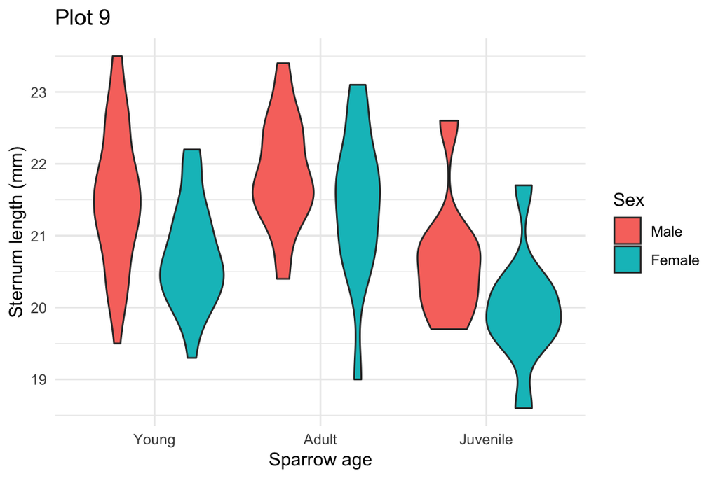

> Hint: Compare this plot to the last one, and don’t overthink!! The code is almost exactly identical.

### Plot 10

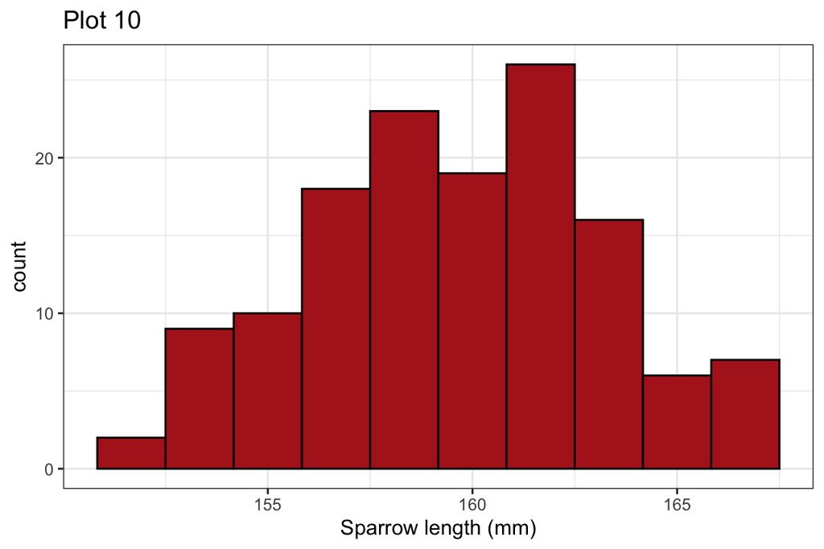

> Hint: Count the bins!